# Actividad 2

2025-08-28

## Equipo 9

#### Se realiza carga de datos:

```r
library(dplyr)

datos <- read.csv2("EP02 Datos.csv")
```

## Preguntas

#### 1) El Comité Olímpico cree que el mejor tiempo medio de los atletas de la zona Centro-Norte después de ingresar al programa de entrenamiento es superior a 13,2 segundos. ¿Soportan los datos esta afirmación?

```r
# Filtrar los datos para la zona Centro-Norte
datosCN <- filter(datos, Zona == "Centro-Norte")

# Obtener los tiempos previos y posteriores al entrenamiento
datosCNPrev <- datosCN$Previo
datosCNPost <-  datosCN$Posterior
```

# Desarrollo de las hipotesis:

#### Hipótesis nula (H₀): La media del tiempo posterior al entrenamiento es menor o igual a 13.2 segundos.

##### H₀: μ ≤ 13.2

#### Hipótesis alternativa (H₁): La media del tiempo posterior al entrenamiento es mayor a 13.2 segundos.

##### H₁: μ > 13.2

### Queremos realizar la prueba t de una muestra, pero primero debemos verificar sus condiciones:

#### 1. Verificamos si las observaciones son independientes entre sí

#### Dado que los datos fueron recolectados de diferentes atletas, podemos asumir que las observaciones son independientes entre sí.

#### 2. Verificamos si los datos siguen una distribución normal con gráfico Q-Q

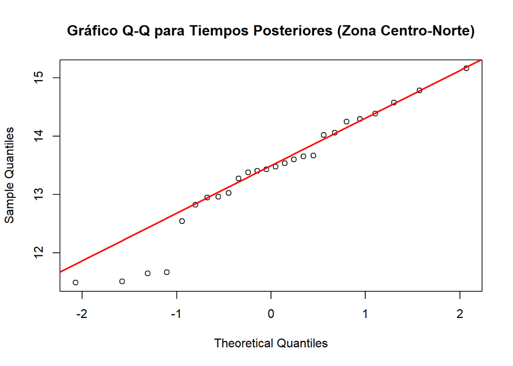

```r
# 1. Crear el gráfico Q-Q de los datos posteriores
qqnorm(datosCNPost, main = "Gráfico Q-Q para Tiempos Posteriores (Zona Centro-Norte)")

# 2. Añadir la línea de referencia de normalidad
qqline(datosCNPost, col = "red", lwd = 2)
```

```r
# Realizar la prueba t de una muestra
resultado1 = t.test(x = datosCNPost, mu = 13.2, alternative = "greater")
resultado1
```

```
##
##  One Sample t-test
##
## data:  datosCNPost
## t = 0.85525, df = 25, p-value = 0.2003
## alternative hypothesis: true mean is greater than 13.2
## 95 percent confidence interval:
##  13.03327      Inf
## sample estimates:
## mean of x
##  13.36719
```

#### El valor p obtenido en la prueba t es de 0.2003, que es mayor que el nivel de significancia comúnmente utilizado (α = 0.05). Por lo tanto, no se rechaza la hipótesis nula.

#### No existe evidencia estadística suficiente para respaldar la afirmación del Comité Olímpico de que el tiempo medio posterior al entrenamiento en la zona Centro-Norte es superior a 13.2 segundos.

## 2) ¿Sugieren los datos que la mejor marca de los atletas de la zona Centro-Sur se reduce en promedio más de 5,2 segundos tras el entrenamiento?

#### Obtenemos los datos de la zona Centro-Sur:

```r
# Filtrar los datos para la zona Centro-Sur
datosCS <- filter(datos, Zona == "Centro-Sur")

# Obtener los tiempos previos y posteriores al entrenamiento
datosCSPrev <-  datosCS$Previo
datosCSPost <-  datosCS$Posterior
```

### Desarrollo de las hipotesis:

##### H₀: μ ≤ 5.2

#### Hipotesis Alternativa H_1: La reduccion promedio en las marcas es > 5.2

##### H₁: μ > 5.2

### Verificación de condiciones para la prueba t de una muestra:

#### 1. Verificamos si las observaciones son independientes entre sí

#### Dado que los datos fueron recolectados de diferentes atletas, podemos asumir que las observaciones son independientes entre sí.

#### 2. Verificamos si los datos siguen una distribución normal con gráfico Q-Q

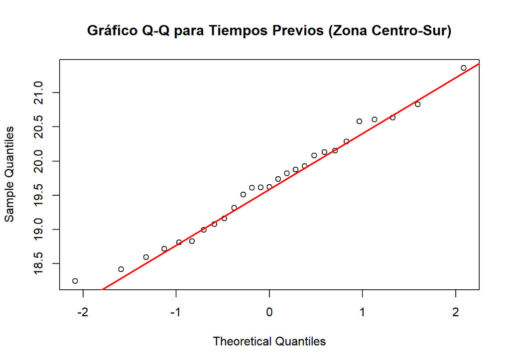

```r
# 1. Crear el gráfico Q-Q de los datos previos
qqnorm(datosCSPrev, main = "Gráfico Q-Q para Tiempos Previos (Zona Centro-Sur)")

# 2. Añadir la línea de referencia de normalidad
qqline(datosCSPrev, col = "red", lwd = 2)
```

#### Como se cumplen las condiciones para realizar la prueba t de una muestra, procedemos a realizarla

```r
# Realizar la prueba t de una muestra
resultado2 = t.test(x = datosCSPrev, mu = 5.2, alternative = "greater")
resultado2
```

```
##
##  One Sample t-test
##
## data:  datosCSPrev
## t = 94.852, df = 26, p-value < 2.2e-16
## alternative hypothesis: true mean is greater than 5.2
## 95 percent confidence interval:
##  19.38998      Inf
## sample estimates:
## mean of x
##  19.64981
```

## 3) ¿Es posible afirmar que, en promedio, los atletas de la zona Sur superan a los de la zona Centro-Norte por 1,3 segundos después del entrenamiento?

#### Se obtienen los datos de ambas zonas:

```r
# Filtrar datos de ambas zonas
datos_CN <- subset(datos, Zona == "Centro-Norte")
datos_Sur <- subset(datos, Zona == "Sur")

# Obtener tiempos posteriores al entrenamiento
tiempos_CN <- datos_CN$Posterior
tiempos_Sur <- datos_Sur$Posterior

# Ver número real de observaciones
cat("Número de atletas Centro-Norte:", length(tiempos_CN), "\n")
```

```
## Número de atletas Centro-Norte: 26
```

```r
cat("Número de atletas Sur:", length(tiempos_Sur), "\n")
```

```
## Número de atletas Sur: 28
```

```r
# Mostrar resumen estadístico
cat("\nResumen - Zona Centro-Norte:\n")
```

```
##
## Resumen - Zona Centro-Norte:
```

```r
summary(tiempos_CN)
```

```
##    Min. 1st Qu.  Median    Mean 3rd Qu.    Max.
##   11.49   12.95   13.45   13.37   14.05   15.16
```

```r
cat("\nResumen - Zona Sur:\n")
```

```
##
## Resumen - Zona Sur:
```

```r
summary(tiempos_Sur)
```

```
##    Min. 1st Qu.  Median    Mean 3rd Qu.    Max.
##   10.69   11.82   12.42   12.55   13.09   15.99
```

#### Verificación de condiciones para la prueba t de dos muestras:

#### 1. Verificamos si las observaciones son independientes entre sí

#### Dado que los datos fueron recolectados de diferentes atletas en distintas zonas, podemos asumir que las observaciones son independientes entre sí.

#### 2. Verificamos si los datos siguen una distribución normal con gráfico Q-Q

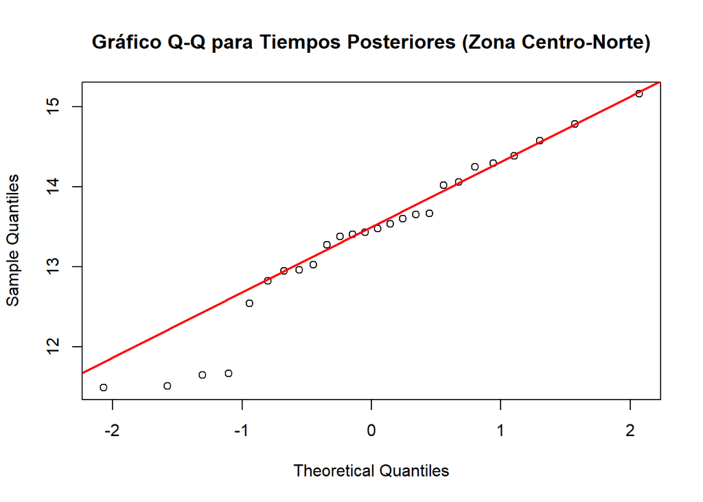

```r
# 1. Crear el gráfico Q-Q de los datos posteriores de la zona Centro-Norte
qqnorm(tiempos_CN, main = "Gráfico Q-Q para Tiempos Posteriores (Zona Centro-Norte)")

# 2. Añadir la línea de referencia de normalidad
qqline(tiempos_CN, col = "red", lwd = 2)
```

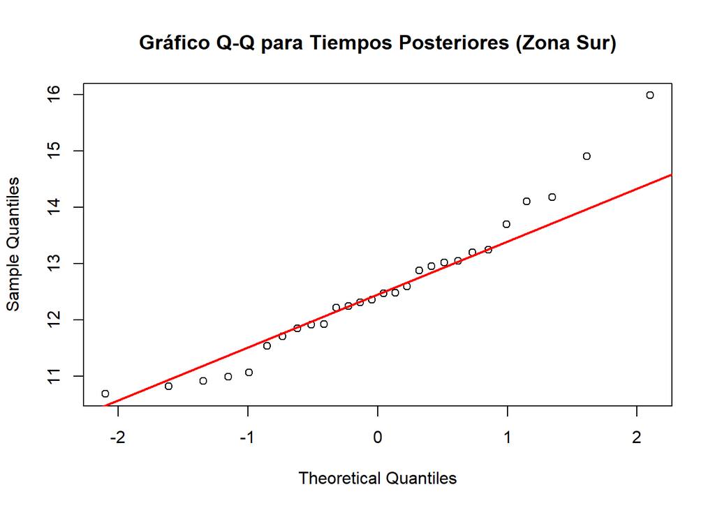

```r
# 3. Crear el gráfico Q-Q de los datos posteriores de la zona Sur
qqnorm(tiempos_Sur, main = "Gráfico Q-Q para Tiempos Posteriores (Zona Sur)")

# 4. Añadir la línea de referencia de normalidad
qqline(tiempos_Sur, col = "red", lwd = 2)
```

#### Como se cumplen las condiciones para realizar la prueba t de dos muestras, procedemos a realizarla

```r
resultado3 <- t.test(x = tiempos_Sur,
                           y = tiempos_CN,
                           mu = 1.3,
                           alternative = "less")
resultado3
```

```
##
##  Welch Two Sample t-test
##
## data:  tiempos_Sur and tiempos_CN
## t = -6.8947, df = 50.809, p-value = 4.064e-09
## alternative hypothesis: true difference in means is less than 1.3
## 95 percent confidence interval:
##        -Inf -0.3047431
## sample estimates:
## mean of x mean of y
##  12.54732  13.36719
```

#### No existe evidencia estadística suficiente para afirmar que, en promedio, los atletas de la zona Sur superen a los de la zona Centro-Norte por más de 1.3 segundos después del entrenamiento.

## 4) ¿Será cierto que hay más atletas de la zona Centro-Norte que redujeron sus mejores marcas en al menos 2,6 segundos que atletas de la zona Sur que lo hicieron en al menos 1,5 segundos?

##### Planteamiento de Hipótesis:

##### Hipótesis nula (H₀): La proporción de atletas que redujeron sus marcas en al menos 2.6 segundos en la zona Centro-Norte es menor o igual que la proporción de atletas que redujeron en al menos 1.5 segundos en la zona Sur.

###### H0: PCN ≤ PSur

##### Hipótesis alternativa (H₁): La proporción de atletas que redujeron sus marcas en al menos 2.6 segundos en la zona Centro-Norte es mayor que la proporción de atletas que redujeron en al menos 1.5 segundos en la zona Sur.

###### H1: PCN > PSur

```r
# Calcular la reducción de tiempo para cada atleta
datos$Reduccion <- datos$Previo - datos$Posterior

# Filtrar datos por zona
datos_CN <- filter(datos, Zona == "Centro-Norte")
datos_Sur <- filter(datos, Zona == "Sur")

# Contar atletas que cumplen con las condiciones de reducción
n_CN <- nrow(datos_CN)
n_Sur <- nrow(datos_Sur)
x_CN <- sum(datos_CN$Reduccion >= 2.6)
x_Sur <- sum(datos_Sur$Reduccion >= 1.5)

# Mostrar resultados
cat("Centro-Norte: ", x_CN, "de", n_CN, "atletas redujeron ≥ 2.6 segundos\n")
```

```
## Centro-Norte:  24 de 26 atletas redujeron ≥ 2.6 segundos
```

```r
cat("Sur: ", x_Sur, "de", n_Sur, "atletas redujeron ≥ 1.5 segundos\n")
```

```
## Sur:  16 de 28 atletas redujeron ≥ 1.5 segundos
```

```r
cat("Proporción Centro-Norte:", round(x_CN/n_CN, 3), "\n")
```

```
## Proporción Centro-Norte: 0.923
```

```r
cat("Proporción Sur:", round(x_Sur/n_Sur, 3), "\n")
```

```
## Proporción Sur: 0.571
```

##### Verificación de condiciones para la prueba de proporciones:

###### Podemos verificar que las muestras son independientes, ya que los atletas de una zona no influyen en los de la otra.

###### Condición de exito y fracaso:

Se realiza la verificacion de exito y fracaso para ambas zonas. Se coloca mayor o igual a 5 para cumplir con la condición.

```r
# Verificar condiciones de éxito y fracaso
n_CN * (x_CN/n_CN) >= 5
```

```
## [1] TRUE
```

```r
n_CN * (1 - x_CN/n_CN) >= 5
```

```
## [1] FALSE
```

```r
n_Sur * (x_Sur/n_Sur) >= 5
```

```
## [1] TRUE
```

```r
n_Sur * (1 - x_Sur/n_Sur) >= 5
```

```
## [1] TRUE
```

```r
# Realizar la prueba de proporciones
resultado4 <- prop.test(x = c(x_CN, x_Sur), n = c(n_CN, n_Sur), alternative = "greater")
resultado4
```

```
##
##  2-sample test for equality of proportions with continuity correction
##
## data:  c(x_CN, x_Sur) out of c(n_CN, n_Sur)
## X-squared = 6.9462, df = 1, p-value = 0.0042
## alternative hypothesis: greater
## 95 percent confidence interval:
##  0.1383433 1.0000000
## sample estimates:
##    prop 1    prop 2
## 0.9230769 0.5714286
```

##### Interpretación de resultados:

##### La prueba de proporciones muestra un valor p de 0.0042 (p < 0.05). Por lo tanto, se rechaza la hipótesis nula. Existe evidencia estadística significativa para afirmar que la proporción de atletas que redujeron sus marcas en al menos 2.6 segundos en la zona Centro-Norte (92.3%) es mayor que la proporción de atletas que redujeron en al menos 1.5 segundos en la zona Sur (57.1%). Esto sugiere que los atletas de la zona Centro-Norte tuvieron un mejor desempeño en términos de reducción de tiempo en comparación con los atletas de la zona Sur.